# Decision Trees

## CP Chart

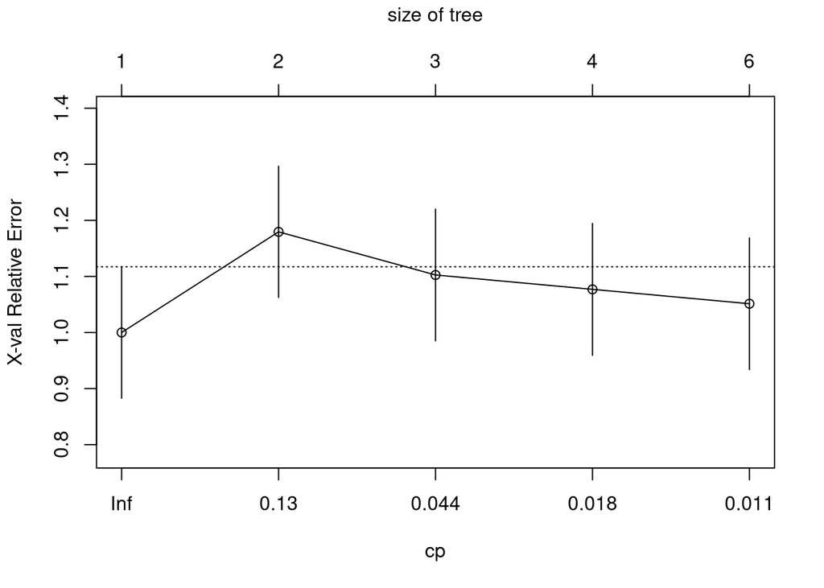

```
## # A tibble: 5 x 5
##       CP nsplit `rel error` xerror  xstd
##    <dbl>  <dbl>       <dbl>  <dbl> <dbl>
## 1 0.231       0       1       1    0.117
## 2 0.0769      1       0.769   1.18 0.117
## 3 0.0256      2       0.692   1.10 0.117
## 4 0.0128      3       0.667   1.08 0.118
## 5 0.01        5       0.641   1.05 0.117
```

Next, we produce a “elbow chart” for various cp values and their associated relative errors. The dashed line represents the highest cross-validated error minus the minimum cross-validated error, plus the standard deviation of the error at that tree. A reasonable choice of cp for pruning is the leftmost value because this is where the mean is less than the horizontal line.

### Variable Importance

```
##                          AJCC.Stage                     Converted.Stage
##                           5.8181441                           4.0991152
##        Days.to.Date.of.Last.Contact                             OS.Time
##                           3.5475117                           3.3240467
##                  Survival.Data.Form                               Tumor
##                           1.9859431                           1.3808629
## Age.at.Initial.Pathologic.Diagnosis                          Node.Coded
##                           1.2467354                           0.9709521
##                   HER2.Final.Status
##                           0.5466472
```

Next, we use the predict function to predict the target variable.

```
##  1  2  3  4  5  6  7  8  9 10 11 12 13 14 15 16 17 18 19 20 21
##  1  0  1  1  0  0  0  0  0  0  0  1  1  0  0  1  0  1  1  1  0
## Levels: 0 1
```

Our test set of size 21 resulted in the prediction of the target variable, the PR Status, as shown above.

## Confusion Matrix

### Hit and Detection Rate

```
## Confusion Matrix and Statistics
##
##           Actual
## Prediction  0  1
##          0  2 10
##          1  4  5
##
##                Accuracy : 0.3333
##                  95% CI : (0.1459, 0.5697)
##     No Information Rate : 0.7143
##     P-Value [Acc > NIR] : 0.9999
##
##                   Kappa : -0.2564
##
##  Mcnemar's Test P-Value : 0.1814
##
##             Sensitivity : 0.3333
##             Specificity : 0.3333
##          Pos Pred Value : 0.5556
##          Neg Pred Value : 0.1667
##              Prevalence : 0.7143
##          Detection Rate : 0.2381
##    Detection Prevalence : 0.4286
##       Balanced Accuracy : 0.3333
##
##        'Positive' Class : 1
##
```

### Best Metrics

```
## [1] 0.6666667
```

```
## [1] 0.2380952
```

The true positive rate could be improved upon as the ideal would create a confusion matrix with a value of 0 in the spot (1,2) also meaning a hit rate of 100%. We would want to focus on a higher hit rate in this specific case because it would be better for the patients to be more careful about their breast cancer diagnosis with a false positive rather than it being kept hidden with a false negative reading. If keeping false positives low was the ideal metric, then we would ideally be looking for a value of 0 in the confusion matrix at the spot (0,0) and also aiming for a high specificity or true negative rate.

## AUC - ROC Curve

```
##
## Call:
## roc.default(response = test$PR.Status, predictor = as.numeric(tree_predict),     plot = TRUE)
##
## Data: as.numeric(tree_predict) in 6 controls (test$PR.Status 0) > 15 cases (test$PR.Status 1).
## Area under the curve: 0.6667
```

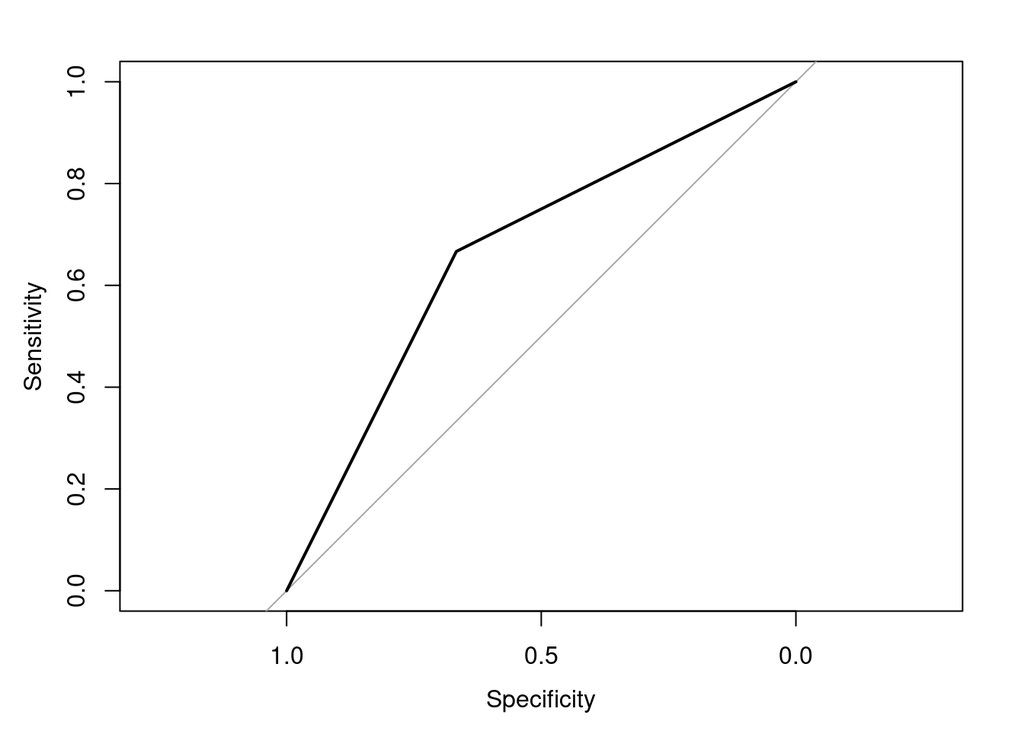

AUC - ROC curve is a performance measurement for the classification problems at various threshold settings. ROC is a probability curve and AUC represents the degree or measure of separability. It tells how much the model is capable of distinguishing between classes. Higher the AUC, the better the model is at predicting 0s as 0s and 1s as 1s.

As shown in the graph, there is a slight inflection point caused by the two rates that causes a deviation from the baseline, but a larger deviation from the line is more desirable and indicates better predicting qualities by the model.